# Title

## Effect size

When using the logistic regression, regression parameters can be directly interpreted as effect size measures. For example, the $\beta_1$ parameter of `fit` model is 1.87 (odds-ratio scale). This means that being in the condition “b” increase the odds of success (accuracy of correctly responding during the task) 1.87 times. Odds and odds ratios are not always easy to interpret. For this reason we can directly compute predicted proababilities that are themselfs directly intepretable in terms of effect sizes. For example the predicted probability for condition “a” is 0.59 and for condition “b” is 0.73. We could also compute a probability ratio where the accuracy of condition “b” is 1.24 times higher than condition “a”. Finally we can convert an odds ratio into Cohen’s $d$ using the formula by Sánchez-Meca and colleagues (Sánchez-Meca, Marı́n-Martı́nez, & Chacón-Moscoso, 2003). The Cohen’s $d$ is 0.35.

If we ignore the binary nature of our variable we can calculate a standard Cohen’s $d$ using accuracy values.

```r
effectsize::cohens_d(acc ~ cond, data = sim)
```

| Cohens_d | CI | CI_low | CI_high |
| --- | --- | --- | --- |
| -1.719796 | 0.95 | -2.309005 | -1.119703 |

Clearly, the Cohen’s $d$ computed from the general linear model is completely misleading.

## Out of bound prediction

Another commonly ignored problem of using a general linear model with binary outcomes is predicting impossible values. Let’s consider a situation where participants performed several trials and we predicted the accuracy using a numeric predictor e.g., participant’s age.

```r
b0 <- 0.84 # accuracy for average age ~ 0.84 ~ qlogis(0.7)
b1 <- 0.05 # increase in the log odds of accuracy for unit increase in age
age <- round(runif(ns, 20, 40))
b0i <- rnorm(ns, 0, tau_id) # random intercepts
sim <- data.frame(id = 1:ns, age = age, b0i = b0i)
sim$age0 <- sim$age - mean(sim$age) # centering
sim$p <- plogis(b0 + sim$b0i + b1 * sim$age0)
sim$nc <- rbinom(nrow(sim), nt, sim$p) # number of correct responses
sim$nf <- nt - sim$nc # number of errors
```

Let’s fit the model:

```r
fit <- glmer(cbind(nc, nf) ~ age0 + (1|id), data = sim, family = binomial(link = "logit"))
summary(fit)
```

```
## Generalized linear mixed model fit by maximum likelihood (Laplace
##   Approximation) [glmerMod]
##  Family: binomial  ( logit )
## Formula: cbind(nc, nf) ~ age0 + (1 | id)
##    Data: sim
##
##      AIC      BIC   logLik deviance df.resid
##    161.6    165.8    -77.8    155.6       27
##
## Scaled residuals:
##     Min      1Q  Median      3Q     Max
## -1.8467 -0.6935  0.1563  0.8118  1.7154
##
## Random effects:
##  Groups Name        Variance  Std.Dev.
##  id     (Intercept) 6.116e-16 2.473e-08
## Number of obs: 30, groups:  id, 30
##
## Fixed effects:
##             Estimate Std. Error z value Pr(>|z|)
## (Intercept)  0.75885    0.05589  13.577  < 2e-16 ***
## age0         0.04718    0.01045   4.516  6.3e-06 ***
## ---
## Signif. codes:  0 '***' 0.001 '**' 0.01 '*' 0.05 '.' 0.1 ' ' 1
##
## Correlation of Fixed Effects:
##      (Intr)
## age0 0.088
## optimizer (Nelder_Mead) convergence code: 0 (OK)
## boundary (singular) fit: see help('isSingular')
```

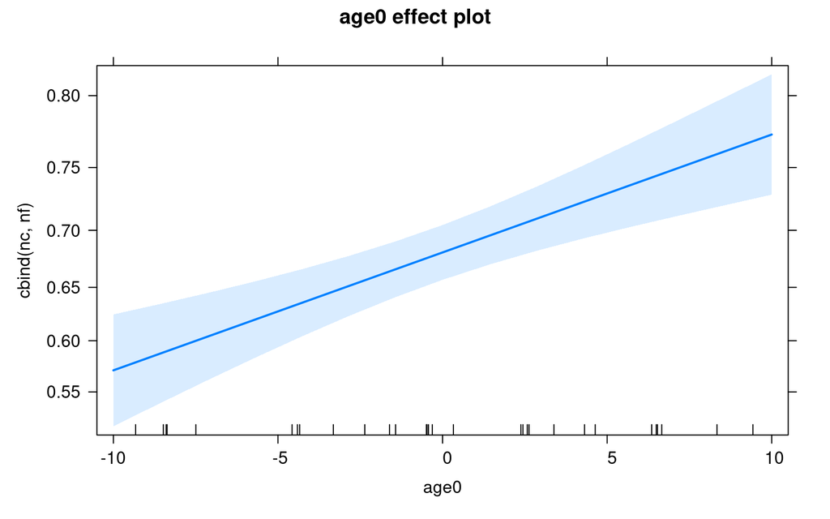

```r
plot(allEffects(fit))
```

Now we can use the model to predict the accuracy of a new participant with an age out of the previous range. The maximum age of the simulation was 40, with a centered value of ~10. Let’s predict a value of 20, 30 and 50 (on the centered scale)

```r
predict(fit, data.frame(age0 = c(20, 30, 50)), re.form = NA, type = "response")
```

```
##         1         2         3
## 0.8458410 0.8978992 0.9576128
```

Clearly the model is taking into account that the probability cannot be higher than 1 thus the effect is increasing and reaching a plateau. Let’s see what happens with the general linear model.

```r
sim$acc <- with(sim, nc / (nc + nf))
fit_lm <- lm(acc ~ age0, data = sim)
summary(fit_lm)
```

```
##
## Call:
## lm(formula = acc ~ age0, data = sim)
##
## Residuals:
##      Min       1Q   Median       3Q      Max
## -0.13164 -0.04367  0.01109  0.05282  0.11669
##
## Coefficients:
##             Estimate Std. Error t value Pr(>|t|)
## (Intercept) 0.678667   0.012366  54.882  < 2e-16 ***
## age0        0.010239   0.002313   4.427 0.000133 ***
## ---
## Signif. codes:  0 '***' 0.001 '**' 0.01 '*' 0.05 '.' 0.1 ' ' 1
##
## Residual standard error: 0.06773 on 28 degrees of freedom
## Multiple R-squared:  0.4117, Adjusted R-squared:  0.3907
## F-statistic:  19.6 on 1 and 28 DF,  p-value: 0.0001326
```

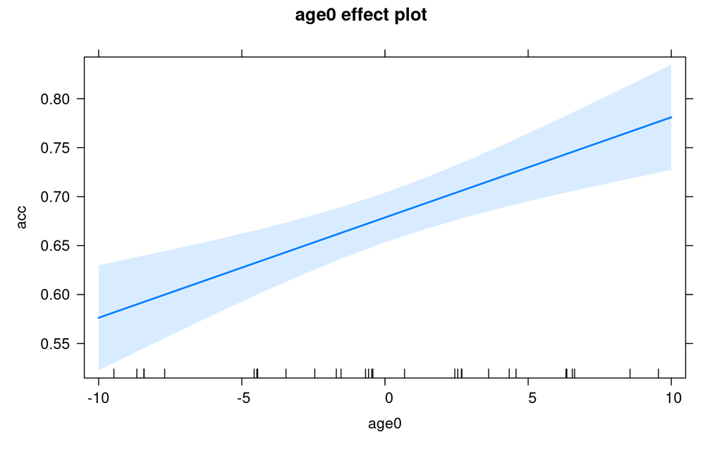

```r
plot(allEffects(fit_lm))
```

And now we can check the predicted values

```r
predict(fit_lm, data.frame(age0 = c(20, 30, 50)))
```

```
##         1         2         3
## 0.8834480 0.9858387 1.1906200
```

Clearly the model is predicting impossible values.

# Packages

- Bates D, Mächler M, Bolker B, Walker S (2015). “Fitting Linear Mixed-Effects Models Using lme4.” *Journal of Statistical Software*, *67*(1), 1-48. doi:10.18637/jss.v067.i01 https://doi.org/10.18637/jss.v067.i01.
- Bates D, Maechler M, Jagan M (2022). *Matrix: Sparse and Dense Matrix Classes and Methods*. R package version 1.5-1, https://CRAN.R-project.org/package=Matrix.
- Fox J, Weisberg S (2019). *An R Companion to Applied Regression*, 3rd edition. Sage, Thousand Oaks CA. https://socialsciences.mcmaster.ca/jfox/Books/Companion/index.html. Fox J, Weisberg S (2018). “Visualizing Fit and Lack of Fit in Complex Regression Models with Predictor Effect Plots and Partial Residuals.” *Journal of Statistical Software*, *87*(9), 1-27. doi:10.18637/jss.v087.i09 https://doi.org/10.18637/jss.v087.i09. Fox J (2003). “Effect Displays in R for Generalised Linear Models.” *Journal of Statistical Software*, *8*(15), 1-27. doi:10.18637/jss.v008.i15 https://doi.org/10.18637/jss.v008.i15. Fox J, Hong J (2009). “Effect Displays in R for Multinomial and Proportional-Odds Logit Models: Extensions to the effects Package.” *Journal of Statistical Software*, *32*(1), 1-24. doi:10.18637/jss.v032.i01 https://doi.org/10.18637/jss.v032.i01.
- Fox J, Weisberg S, Price B (2022). *carData: Companion to Applied Regression Data Sets*. R package version 3.0-5, https://CRAN.R-project.org/package=carData.
- Grolemund G, Wickham H (2011). “Dates and Times Made Easy with lubridate.” *Journal of Statistical Software*, *40*(3), 1-25. https://www.jstatsoft.org/v40/i03/.
- Müller K, Wickham H (2023). *tibble: Simple Data Frames*. R package version 3.2.0, https://CRAN.R-project.org/package=tibble.
- R Core Team (2022). *R: A Language and Environment for Statistical Computing*. R Foundation for Statistical Computing, Vienna, Austria. https://www.R-project.org/.
- Wickham H (2016). *ggplot2: Elegant Graphics for Data Analysis*. Springer-Verlag New York. ISBN 978-3-319-24277-4, https://ggplot2.tidyverse.org.
- Wickham H (2022). *stringr: Simple, Consistent Wrappers for Common String Operations*. R package version 1.5.0, https://CRAN.R-project.org/package=stringr.
- Wickham H (2023). *forcats: Tools for Working with Categorical Variables (Factors)*. R package version 1.0.0, https://CRAN.R-project.org/package=forcats.
- Wickham H, Averick M, Bryan J, Chang W, McGowan LD, François R, Grolemund G, Hayes A, Henry L, Hester J, Kuhn M, Pedersen TL, Miller E, Bache SM, Müller K, Ooms J, Robinson D, Seidel DP, Spinu V, Takahashi K, Vaughan D, Wilke C, Woo K, Yutani H (2019). “Welcome to the tidyverse.” *Journal of Open Source Software*, *4*(43), 1686. doi:10.21105/joss.01686 https://doi.org/10.21105/joss.01686.
- Wickham H, François R, Henry L, Müller K, Vaughan D (2023). *dplyr: A Grammar of Data Manipulation*. R package version 1.1.0, https://CRAN.R-project.org/package=dplyr.
- Wickham H, Henry L (2023). *purrr: Functional Programming Tools*. R package version 1.0.1, https://CRAN.R-project.org/package=purrr.
- Wickham H, Hester J, Bryan J (2023). *readr: Read Rectangular Text Data*. R package version 2.1.4, https://CRAN.R-project.org/package=readr.
- Wickham H, Vaughan D, Girlich M (2023). *tidyr: Tidy Messy Data*. R package version 1.3.0, https://CRAN.R-project.org/package=tidyr.

# References

Sánchez-Meca, J., Marı́n-Martı́nez, F., & Chacón-Moscoso, S. (2003). Effect-size indices for dichotomized outcomes in meta-analysis. *Psychol. Methods*, *8*(4), 448–467. https://doi.org/10.1037/1082-989X.8.4.448